# A3: Incarceration

### Summary Information

While examining the data, I could see that it shows that people of color are incarcerated at significantly higher rates than white people, with black people being incarcerated the most. The average prison population of white people per 100,00 is 437.48. The average prison population of native people per 100,00 is 640.16. The average prison population of latinx people per 100,00 is 776.16. The average prison population of aapi people per 100,00 is 34.72. The average prison population of black people per 100,00 is 2785.15. The average for black people is the highest, followed by latinx people, native people, white people, and finally AAPI people.

### The Dataset

The data was collected by the Vera Institute of Justice. They merged data from multiple datasets such as the Census of Jails (COJ), the Annual Survey of Jails (ASJ), and BJS National Corrections Reporting Program (NCRP). They collect this data because they believe that by examining the data and identifying trends within the dataset, we can create programs and initiatives to end mass incarceration. There are 23 features of the dataset and 91031 observations. Working with the Vera Institute of Justice incarceration trends dataset raises important ethical questions and considerations regarding privacy, fairness, and consent. Researchers must ensure the confidentiality of individuals’ information and be mindful of potential biases in the data. Striving for transparency and accountability in research methods is crucial to address power imbalances and minimize harm while conducting responsible analysis.The Vera Institute of Justice incarceration trends dataset, while valuable, comes with certain limitations that researchers need to acknowledge. One potential concern is data quality, as criminal justice data may be susceptible to errors, omissions, or inconsistencies. For example, there are multiple rural regions that do not have data regarding the race of prisoners, which results in gaps in the data. Additionally, the dataset might lack critical variables that influence incarceration trends, such as socioeconomic factors or mental health issues. Selection bias can also be a concern, as the dataset may not represent the entire criminal justice system accurately. Moreover, the dynamic nature of definitions and practices over time makes it challenging to compare trends across different periods. Researchers must tread carefully, utilize robust methodologies, and consider alternative data sources to address these limitations and produce reliable and insightful findings.

### Trends Over Time Chart

This is a chart comparing the mean prison populations of white men and black men. I included this chart in order to highlight racial inequalities of incarceration rates. As you can see, there was a large spike in the prison population around 1997, but black male prison rates are significantly higher than white male prison rates.

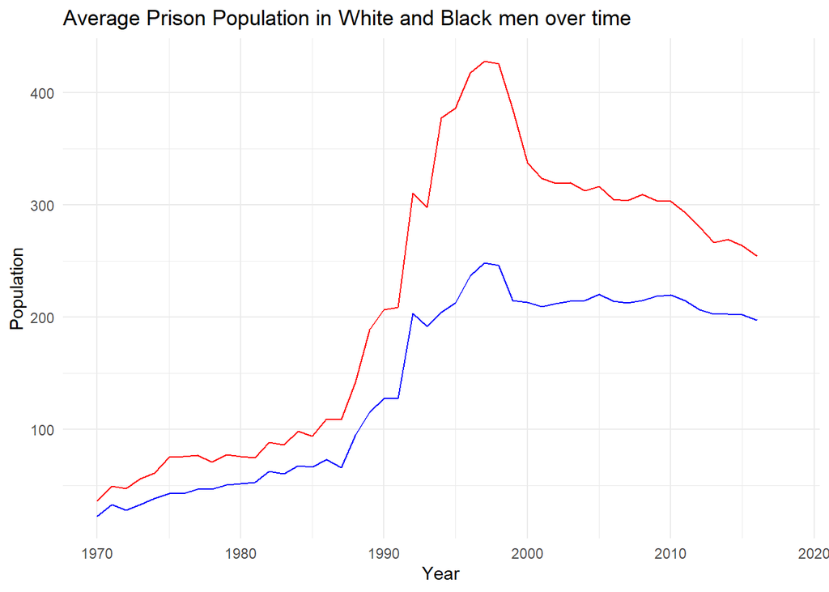

### Variable Comparison Chart

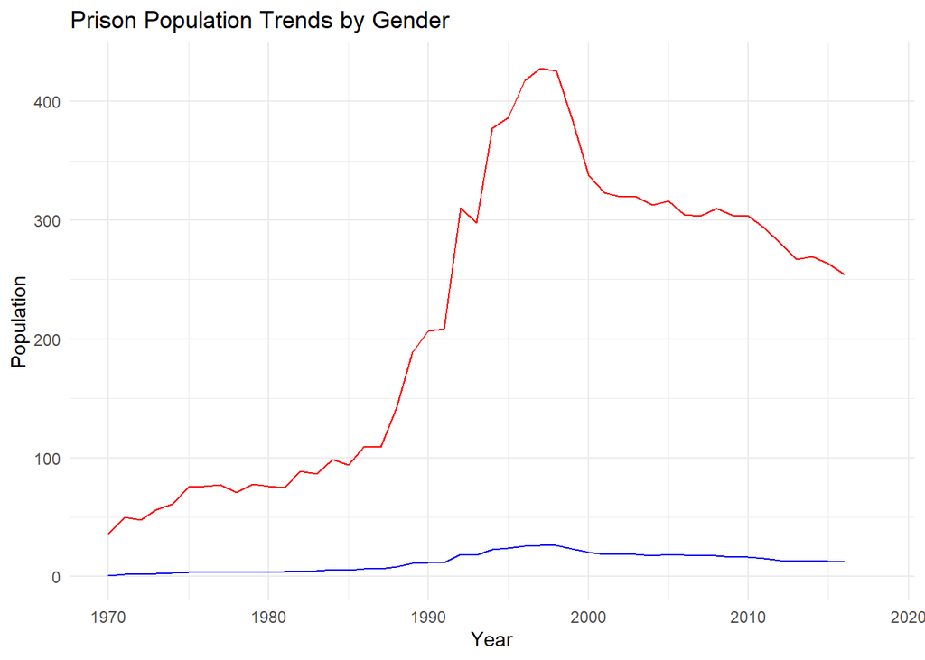

### Map

[output not shown]

[output not shown]

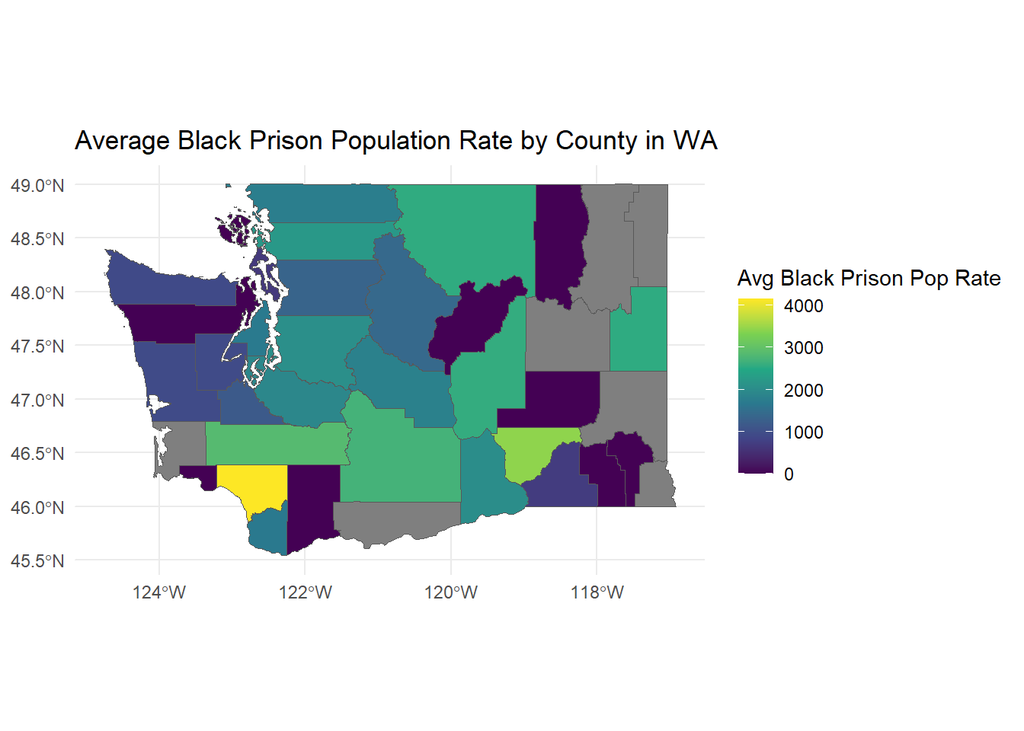